# Homework 08

The former kernel-tuning question has moved to Homework 09.

Solutions for Questions 1 and 2 will be available after Monday, October 19, 2026. No solution can be provided for Question 3.

For Questions 1 and 2, use either R or Python.

## Question 1: Boundary and margin

Use `margin-geometry-20.csv` from the combined ZIP, which contains 20 observations with predictors $x_1,x_2$ and class labels $y\in\{-1,1\}$. Consider the score

$$f(x)=0.8x_1+0.6x_2.$$

Since $\|(0.8,0.6)\|_2=1$, the lines $f(x)=\pm1$ are each a distance 1 from the decision boundary $f(x)=0$.

1. Calculate the distance from every observation to the decision boundary and its functional margin $yf(x)$. In a table, report these values and whether each observation is inside, on, or beyond the margin for its class. Compare $yf(x)$ with 1 to make this distinction.

```r
d1 <- read.csv("margin-geometry-20.csv")

names(d1)
```

```
[1] "observation" "x1"          "x2"          "y"
```

```r
# Replace "obs" with the actual observation-number column name.
id_col <- "observation"

stopifnot(
  all(c(id_col, "x1", "x2", "y") %in% names(d1)),
  all(d1$y %in% c(-1, 1))
)

d1$observation <- d1[[id_col]]

# Given score: do not fit a new classifier.
d1$score <- 0.8 * d1$x1 + 0.6 * d1$x2

d1$distance <- abs(d1$score)
d1$functional_margin <- d1$y * d1$score

# Tolerance avoids treating floating-point rounding as a real difference.
tol <- 1e-8

d1$position <- ifelse(
  d1$functional_margin < 1 - tol, "Inside",
  ifelse(
    d1$functional_margin > 1 + tol,
    "Beyond",
    "On"
  )
)

d1$prediction <- sign(d1$score)

d1$result <- ifelse(
  d1$score == 0, "On decision boundary",
  ifelse(d1$functional_margin < 0, "Misclassified", "Correct")
)

answer_1a <- d1[, c(
  "observation", "x1", "x2", "y",
  "score", "distance", "functional_margin",
  "position", "result"
)]

knitr::kable(answer_1a, digits = 4)
```

| observation | x1 | x2 | y | score | distance | functional_margin | position | result |
| --- | --- | --- | --- | --- | --- | --- | --- | --- |
| 1 | 0.68 | 0.76 | 1 | 1.00 | 1.00 | 1.00 | On | Correct |
| 2 | 1.80 | -0.15 | 1 | 1.35 | 1.35 | 1.35 | Beyond | Correct |
| 3 | 1.38 | 0.66 | 1 | 1.50 | 1.50 | 1.50 | Beyond | Correct |
| 4 | 0.88 | 1.66 | 1 | 1.70 | 1.70 | 1.70 | Beyond | Correct |
| 5 | 0.62 | 2.34 | 1 | 1.90 | 1.90 | 1.90 | Beyond | Correct |
| 6 | 2.78 | -0.04 | 1 | 2.20 | 2.20 | 2.20 | Beyond | Correct |
| 7 | 1.86 | 1.52 | 1 | 2.40 | 2.40 | 2.40 | Beyond | Correct |
| 8 | 0.50 | 0.40 | 1 | 0.64 | 0.64 | 0.64 | Inside | Correct |
| 9 | 0.10 | 0.20 | 1 | 0.20 | 0.20 | 0.20 | Inside | Correct |
| 10 | -0.40 | 0.20 | 1 | -0.20 | 0.20 | -0.20 | Inside | Misclassified |
| 11 | -0.92 | -0.44 | -1 | -1.00 | 1.00 | 1.00 | On | Correct |
| 12 | -0.50 | -1.50 | -1 | -1.30 | 1.30 | 1.30 | Beyond | Correct |
| 13 | -1.90 | -0.05 | -1 | -1.55 | 1.55 | 1.55 | Beyond | Correct |
| 14 | -0.44 | -2.33 | -1 | -1.75 | 1.75 | 1.75 | Beyond | Correct |
| 15 | -1.98 | -0.61 | -1 | -1.95 | 1.95 | 1.95 | Beyond | Correct |
| 16 | -2.74 | 0.07 | -1 | -2.15 | 2.15 | 2.15 | Beyond | Correct |
| 17 | -1.90 | -1.55 | -1 | -2.45 | 2.45 | 2.45 | Beyond | Correct |
| 18 | -0.50 | -0.40 | -1 | -0.64 | 0.64 | 0.64 | Inside | Correct |
| 19 | 0.00 | -0.40 | -1 | -0.24 | 0.24 | 0.24 | Inside | Correct |
| 20 | 0.40 | -0.20 | -1 | 0.20 | 0.20 | -0.20 | Inside | Misclassified |

Since $\|\boldsymbol{\beta}\|=\sqrt{0.8^2+0.6^2}=1$, the distance from observation $i$ to the decision boundary is

$$d_i=\frac{|f(x_i)|}{\|\boldsymbol{\beta}\|}
=|0.8x_{i1}+0.6x_{i2}|.$$

The functional margin is $y_i f(x_i)$. An observation is inside, on, or beyond its class margin when its functional margin is less than, equal to, or greater than 1, respectively. The table above reports these quantities for all 20 observations.

Observations 8, 9, 10, 18, 19, and 20 are inside their class margins. Observations 1 and 11 are on their class margins, and the remaining observations are beyond their class margins. A negative functional margin indicates misclassification; a functional margin between 0 and 1 indicates correct classification within the margin.

2. Plot the observations, the boundary $f(x)=0$, and the margin lines $f(x)=\pm1$. Distinguish the two classes and identify the observations inside the margin in your plot.

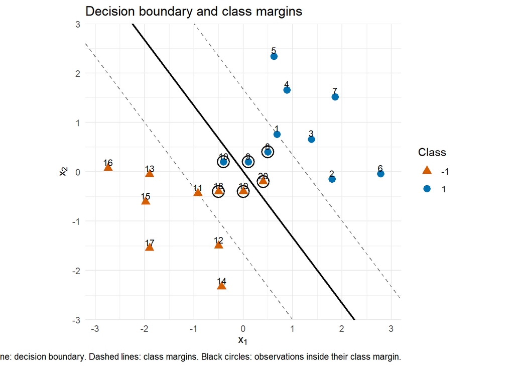

```r
library(ggplot2)

ggplot(
  d1,
  aes(x = x1, y = x2)
) +
  # Decision boundary: f(x) = 0
  geom_abline(
    intercept = 0,
    slope = -4 / 3,
    linewidth = 0.8
  ) +
  # Margin lines: f(x) = +/- 1
  geom_abline(
    intercept = c(-5 / 3, 5 / 3),
    slope = -4 / 3,
    linetype = "dashed",
    color = "gray45"
  ) +
  geom_point(
    aes(color = factor(y), shape = factor(y)),
    size = 3
  ) +
  # Circle observations inside their class margin.
  geom_point(
    data = subset(d1, position == "Inside"),
    shape = 1,
    size = 5,
    stroke = 1,
    color = "black"
  ) +
  geom_text(
    aes(label = observation),
    nudge_y = 0.12,
    size = 3,
    show.legend = FALSE
  ) +
  scale_color_manual(
    values = c("-1" = "#D55E00", "1" = "#0072B2"),
    name = "Class"
  ) +
  scale_shape_manual(
    values = c("-1" = 17, "1" = 16),
    name = "Class"
  ) +
  coord_fixed(
    ratio = 1,
    xlim = c(-3.2, 3.2),
    ylim = c(-3, 3),
    expand = FALSE
  ) +
  labs(
    x = expression(x[1]),
    y = expression(x[2]),
    title = "Decision boundary and class margins",
    caption = paste(
      "Solid line: decision boundary.",
      "Dashed lines: class margins.",
      "Black circles: observations inside their class margin."
    )
  ) +
  theme_minimal()
```

The decision boundary and margin lines are

$$\begin{aligned}
f(x)=0 &: \quad x_2=-\frac{4}{3}x_1,\\
f(x)=1 &: \quad x_2=-\frac{4}{3}x_1+\frac{5}{3},\\
f(x)=-1 &: \quad x_2=-\frac{4}{3}x_1-\frac{5}{3}.
\end{aligned}$$

The plot displays the decision boundary as a solid line and the margin lines as dashed lines. Colors and shapes distinguish the two classes, and black circles identify observations 8, 9, 10, 18, 19, and 20 as being inside their class margins. Each margin line is 1 unit from the decision boundary.

3. Report how many observations are inside, on, and beyond the margin. Which observations are misclassified by this decision rule?

Use the observation numbers supplied in the data. Set the $x_1$ axis to $[-3.2,3.2]$, set the $x_2$ axis to $[-3,3]$, and use an equal aspect ratio. Do not fit a new classifier for this question.

```r
# Counts for all three categories, including any zero counts.
margin_counts <- table(
  factor(
    d1$position,
    levels = c("Inside", "On", "Beyond")
  )
)

margin_counts
```

```
Inside     On Beyond
     6      2     12
```

```r
# Misclassified observations.
misclassified <- subset(
  d1,
  functional_margin < 0,
  select = c(
    observation, x1, x2, y,
    score, functional_margin
  )
)

knitr::kable(misclassified, digits = 4)
```

|  | observation | x1 | x2 | y | score | functional_margin |
| --- | --- | --- | --- | --- | --- | --- |
| 10 | 10 | -0.4 | 0.2 | 1 | -0.2 | -0.2 |
| 20 | 20 | 0.4 | -0.2 | -1 | 0.2 | -0.2 |

```r
# Check for observations exactly on the decision boundary.
subset(d1, score == 0)
```

```
 [1] observation       x1                x2                y
 [5] score             distance          functional_margin position
 [9] prediction        result
<0 行> (或0-长度的row.names)
```

There are 6 observations inside, 2 on, and 12 beyond their class margins.

Observations 10 and 20 are misclassified:

- Observation 10 has $y=1$ but $f(x)=-0.2$, so it is predicted as class $-1$.
- Observation 20 has $y=-1$ but $f(x)=0.2$, so it is predicted as class $1$.

Both have a functional margin of $-0.2$. No observations lie exactly on the decision boundary. The classification error rate is $2/20=10\%$.

## Question 2: Margin in four dimensions

Use `margin-geometry-4d.csv` from the combined ZIP, which contains 50 observations with four predictors and class labels $y\in\{-1,1\}$. Consider the linear score

$$f(\mathbf{x})=\beta_0+\mathbf{x}^{\mathsf T}\boldsymbol{\beta},
\qquad
\beta_0=-1,
\quad
\boldsymbol{\beta}=(1,2,-2,4)^{\mathsf T}.$$

1. Project the observations onto the direction of $\boldsymbol{\beta}$ and plot their positions on one axis. Distinguish the two classes and mark the decision boundary. Use the plot to calculate the geometric margin $M$, the distance from the boundary to the closest observation.

```r
d2 <- read.csv("margin-geometry-4d.csv")

names(d2)
```

```
[1] "observation" "x1"          "x2"          "x3"          "x4"
[6] "y"
```

```r
# Adjust these names if the CSV uses x_1, x_2, etc.
predictor_cols <- c("x1", "x2", "x3", "x4")

stopifnot(
  all(c(predictor_cols, "y") %in% names(d2)),
  all(d2$y %in% c(-1, 1))
)

X <- as.matrix(d2[, predictor_cols])

beta <- c(1, 2, -2, 4)
beta0 <- -1

beta_norm <- sqrt(sum(beta^2))
unit_direction <- beta / beta_norm

d2$projection <- drop(X %*% unit_direction)
d2$score <- beta0 + drop(X %*% beta)
d2$functional_margin <- d2$y * d2$score

boundary <- -beta0 / beta_norm

d2$distance <- abs(d2$projection - boundary)

M <- min(d2$distance)

cat("Norm of beta:", beta_norm, "\n")
```

```
Norm of beta: 5
```

```r
cat("Boundary on projection axis:", boundary, "\n")
```

```
Boundary on projection axis: 0.2
```

```r
cat("Geometric margin M:", M, "\n")
```

```
Geometric margin M: 1
```

```r
# Rows containing the closest observations.
d2[
  abs(d2$distance - M) < 1e-8,
  c(predictor_cols, "y", "projection", "score", "distance")
]
```

```
      x1    x2    x3    x4  y projection score distance
4  -1.26 -0.27 -1.98  0.96  1        1.2     5        1
15 -6.16  1.18  0.32  0.11 -1       -0.8    -5        1
33  7.74  1.23  1.02 -0.54  1        1.2     5        1
36  2.84  0.43 -0.43 -2.14 -1       -0.8    -5        1
```

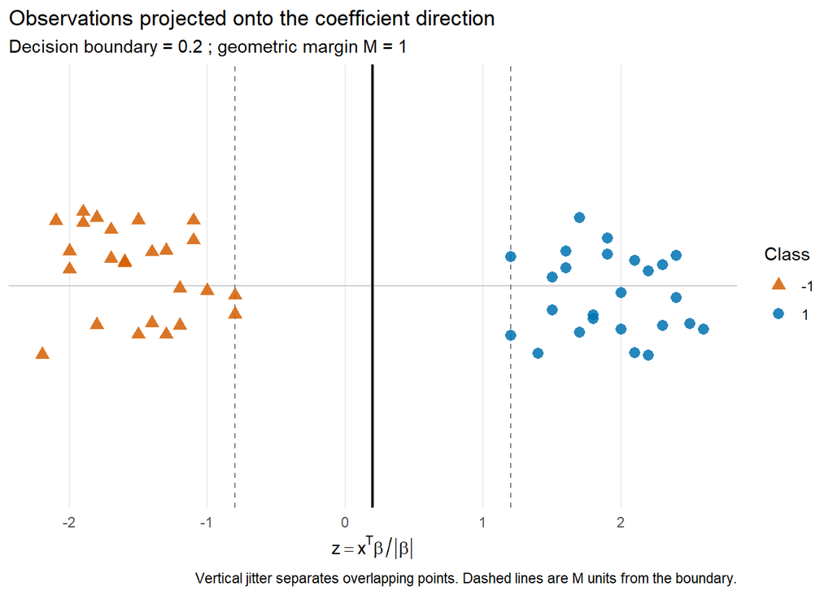

```r
library(ggplot2)

ggplot(
  d2,
  aes(
    x = projection,
    y = 0,
    color = factor(y),
    shape = factor(y)
  )
) +
  geom_hline(
    yintercept = 0,
    color = "gray80"
  ) +
  geom_vline(
    xintercept = boundary,
    linewidth = 0.8
  ) +
  geom_vline(
    xintercept = boundary + c(-M, M),
    linetype = "dashed",
    color = "gray50"
  ) +
  # Vertical jitter only; horizontal projection positions are unchanged.
  geom_point(
    position = position_jitter(
      width = 0,
      height = 0.045,
      seed = 432
    ),
    size = 2.8,
    alpha = 0.85
  ) +
  scale_color_manual(
    values = c("-1" = "#D55E00", "1" = "#0072B2"),
    name = "Class"
  ) +
  scale_shape_manual(
    values = c("-1" = 17, "1" = 16),
    name = "Class"
  ) +
  scale_y_continuous(
    breaks = NULL,
    limits = c(-0.12, 0.12)
  ) +
  labs(
    x = expression(z == x^T * beta / group("||", beta, "||")),
    y = NULL,
    title = "Observations projected onto the coefficient direction",
    subtitle = paste(
      "Decision boundary =",
      round(boundary, 4),
      "; geometric margin M =",
      round(M, 4)
    ),
    caption = paste(
      "Vertical jitter separates overlapping points.",
      "Dashed lines are M units from the boundary."
    )
  ) +
  theme_minimal() +
  theme(
    panel.grid.major.y = element_blank(),
    panel.grid.minor = element_blank()
  )
```

The norm of the coefficient vector is

$$\|\boldsymbol{\beta}\|
=\sqrt{1^2+2^2+(-2)^2+4^2}
=5.$$

Thus, the unit vector in its direction is

$$\mathbf{u}
=\frac{\boldsymbol{\beta}}{5}
=(0.2,0.4,-0.4,0.8)^{\mathsf T}.$$

The scalar projection of observation $i$ onto this direction is

$$z_i
=\mathbf{x}_i^{\mathsf T}\mathbf{u}
=\frac{x_{i1}+2x_{i2}-2x_{i3}+4x_{i4}}{5}.$$

Since $f(\mathbf{x}_i)=-1+5z_i$, the decision boundary corresponds to $z=0.2$. The closest projected observations occur at $z=-0.8$ and $z=1.2$, each 1 unit from the boundary. Therefore,

$$\boxed{M=\min_i |z_i-0.2|=1.}$$

Equivalently, the smallest absolute score is 5, giving $M=5/\|\boldsymbol{\beta}\|=1$.

2. Express the same decision boundary using the SVM normalization in which the smallest functional margin $y_i f(\mathbf{x}_i)$ is set to 1. What are the corresponding values of $\boldsymbol{\beta}$ and $\beta_0$?

```r
m <- min(d2$functional_margin)

cat("Smallest original functional margin:", m, "\n")
```

```
Smallest original functional margin: 5
```

```r
if (m > 0) {

  beta_svm <- beta / m
  beta0_svm <- beta0 / m

  normalized_coefficients <- data.frame(
    coefficient = c("Intercept", predictor_cols),
    value = c(beta0_svm, beta_svm)
  )

  print(normalized_coefficients)

  # Verify that the minimum functional margin is 1.
  normalized_score <- beta0_svm + drop(X %*% beta_svm)

  cat(
    "Smallest normalized functional margin:",
    min(d2$y * normalized_score),
    "\n"
  )

  # Verify M = 1 / ||beta_svm||.
  cat(
    "Margin from normalized coefficients:",
    1 / sqrt(sum(beta_svm^2)),
    "\n"
  )

} else {

  cat(
    "The given rule does not strictly classify all observations correctly.\n",
    "Positive rescaling cannot make every functional margin at least 1.\n"
  )

}
```

```
  coefficient value
1   Intercept  -0.2
2          x1   0.2
3          x2   0.4
4          x3  -0.4
5          x4   0.8
Smallest normalized functional margin: 1
Margin from normalized coefficients: 1
```

The smallest original functional margin is

$$\min_i y_i f(\mathbf{x}_i)=5.$$

Dividing both the intercept and the coefficient vector by 5 makes the smallest functional margin equal to 1. The normalized coefficients are therefore

$$\boxed{
\beta_0^*=-0.2,
\qquad
\boldsymbol{\beta}^*
=(0.2,0.4,-0.4,0.8)^{\mathsf T}.
}$$

The normalized score is

$$f^*(\mathbf{x})
=-0.2+0.2x_1+0.4x_2-0.4x_3+0.8x_4
=\frac{f(\mathbf{x})}{5}.$$

This positive rescaling preserves the decision boundary and all predicted classes, while ensuring

$$\min_i y_i f^*(\mathbf{x}_i)=1.$$

Finally, $\|\boldsymbol{\beta}^*\|=1$, so the geometric margin remains

$$M=\frac{1}{\|\boldsymbol{\beta}^*\|}=1.$$

## Question 3: Peer review of a Homework 7 skill

The instructor’s GitHub account, **rqzhu-aide**, will open a **GitHub Issue** in the repository containing your Homework 7 submission. It will link to **one** assigned student’s repository.

1. **Use the skill.** Find the complete skill definition in the assigned student’s Homework 7 report. Copy it without changes into a local `SKILL.md` file in your own folder. You do not need to install it. Give your agent the path to the file and explicitly ask it to follow that skill while analyzing the `SAheart` data, using the response and predictor coding from Homework 7. Provide the necessary data information, but no additional preferences about methods, figures, model selection, or report style. Let the skill direct the analysis.

   Monitor the time, your token use, and your weekly quota while the agent works. If the run is taking too long or using your allowance too quickly, you may send a **steer message** asking the agent to finish immediately, or stop the run and summarize what you observed. A steer message redirects an agent while it is working; learn how to send one in your AI tool before starting.
2. **Write a peer review.** Read the student’s submitted report and what the skill produced in your run. Give a brief overall assessment, followed by **three major items the author could improve**. You may comment on any aspect of the skill or report. For each item, explain what you observed, why it matters, and what you recommend changing. If you stopped the run early, explain where and why. Write the review yourself, without AI assistance.
3. **Share your review.** Open a GitHub Issue in the assigned student’s Homework 7 repository containing your review. Copy the same review into your Homework 8 submission report and include a link to the GitHub Issue.

The report is concise, well-organized, and follows the skill’s requirements. It documents shared CV folds, preprocessing within folds, and selection independent of test results. It also acknowledges poor test performance. The evidence for model selection and the materials needed to reproduce the analysis could be further strengthened.

1. Make class-specific performance central to evaluation. The selected model’s test error is 34.53%, equal to always predicting class 0, and its sensitivity is only 33.3%. Although these findings appear in the text, the comparison table emphasizes overall error alone. This can obscure poor performance for the minority class. I recommend adding a majority-class benchmark and reporting sensitivity, specificity, and balanced accuracy alongside overall error. Any alternative selection metric or error costs should be defined before examining test results.
2. Make the figure more informative. The figure largely repeats the CV errors already shown in the table. The difference between PCA-QDA (2) and LDA is particularly small and difficult to assess visually. Adding exact values beside these two points, or noting that the selected model makes only one fewer CV error than LDA, would help readers understand the size of the improvement.
3. Present the numerical results more clearly. The model parameters and confusion matrix are presented as inline text with brackets, which makes them difficult to read quickly. Displaying the confusion matrix with clearly labeled observed and predicted classes, and aligning the model parameters by class, would make the results easier to interpret and check.